# R básico para ciencia de datos - Clase 3

Ph D. Stephanie Hereira-Pacheco

Universidad Autónoma de Tlaxcala

2026-05-21

## Estadísticos básicos en R — Clase 3

- Estadísticos descriptivos
- Gráficos descriptivos
- Exploración de normalidad
- Correlación y Regresión lineal
- ANOVA (1 vía y 2 vías)
- Prueba de Tukey
- Otras pruebas

## Dataset de trabajo

Trabajaremos con el dataset `iris` — medidas de sépalos y pétalos de tres especies de flores.

```r
data(iris)
cols <- c("Largo_Sepalo", "Ancho_Sepalo", "Largo_Petalo",
          "Ancho_Petalo", "Especies")
colnames(iris) <- cols
str(iris)
```

```
'data.frame':   150 obs. of  5 variables:
 $ Largo_Sepalo: num  5.1 4.9 4.7 4.6 5 5.4 4.6 5 4.4 4.9 ...
 $ Ancho_Sepalo: num  3.5 3 3.2 3.1 3.6 3.9 3.4 3.4 2.9 3.1 ...
 $ Largo_Petalo: num  1.4 1.4 1.3 1.5 1.4 1.7 1.4 1.5 1.4 1.5 ...
 $ Ancho_Petalo: num  0.2 0.2 0.2 0.2 0.2 0.4 0.3 0.2 0.2 0.1 ...
 $ Especies    : Factor w/ 3 levels "setosa","versicolor",..: 1 1 1 1 1 1 1 1 1 1 ...
```

## Dataset de trabajo

4 variables numéricas de respuesta y 1 factor (especie):

```r
dim(iris)
```

```
[1] 150   5
```

```r
nrow(iris)
```

```
[1] 150
```

```r
ncol(iris)
```

```
[1] 5
```

## Dataset de trabajo: especies

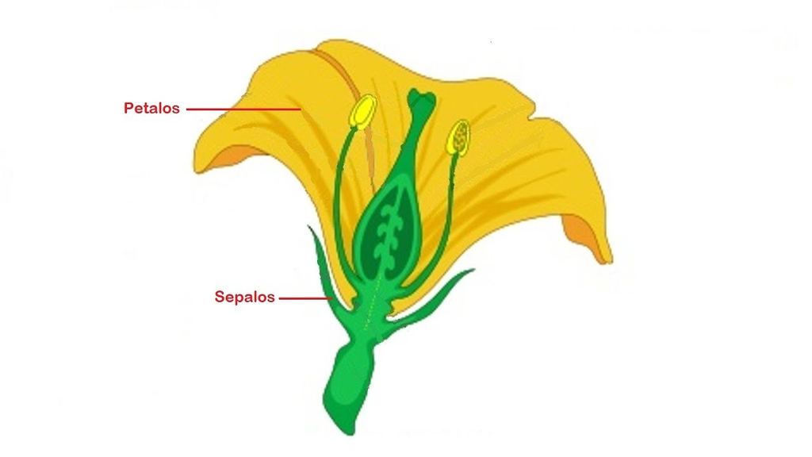

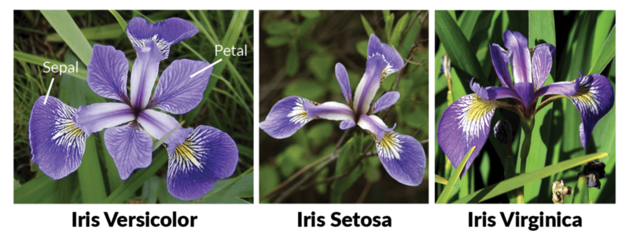

## Estadísticos descriptivos: `summary()`

`summary()` devuelve mínimo, máximo, promedio, mediana y rango intercuartil de cada variable:

```r
summary(iris)
```

```
  Largo_Sepalo    Ancho_Sepalo    Largo_Petalo    Ancho_Petalo
 Min.   :4.300   Min.   :2.000   Min.   :1.000   Min.   :0.100
 1st Qu.:5.100   1st Qu.:2.800   1st Qu.:1.600   1st Qu.:0.300
 Median :5.800   Median :3.000   Median :4.350   Median :1.300
 Mean   :5.843   Mean   :3.057   Mean   :3.758   Mean   :1.199
 3rd Qu.:6.400   3rd Qu.:3.300   3rd Qu.:5.100   3rd Qu.:1.800
 Max.   :7.900   Max.   :4.400   Max.   :6.900   Max.   :2.500
       Especies
 setosa    :50
 versicolor:50
 virginica :50
```

## Estadísticos descriptivos: tendencia central

```r
mean(iris$Largo_Sepalo)
```

```
[1] 5.843333
```

```r
median(iris$Largo_Sepalo)
```

```
[1] 5.8
```

```r
min(iris$Largo_Sepalo)
```

```
[1] 4.3
```

```r
max(iris$Largo_Sepalo)
```

```
[1] 7.9
```

## Estadísticos descriptivos: cuantiles y dispersión

```r
quantile(iris$Largo_Sepalo, 0.25)                  # primer cuartil
```

```
25%
5.1
```

```r
quantile(iris$Largo_Sepalo, 0.75)                  # tercer cuartil
```

```
75%
6.4
```

```r
sd(iris$Largo_Sepalo)                              # desviación estándar
```

```
[1] 0.8280661
```

```r
IQR(iris$Largo_Sepalo)                             # rango intercuartil
```

```
[1] 1.3
```

## Estadísticos descriptivos: variabilidad

```r
var(iris$Largo_Sepalo)                             # varianza
```

```
[1] 0.6856935
```

```r
sd(iris$Largo_Sepalo) / mean(iris$Largo_Sepalo)    # coeficiente de variación
```

```
[1] 0.1417113
```

Para calcular la SD de todas las columnas numéricas:

```r
lapply(iris[, 1:4], sd)
```

[output not shown]

## Gráficos descriptivos: boxplot

Variación del largo del sépalo por especie:

```r
boxplot(iris$Largo_Sepalo ~ iris$Especies)
```

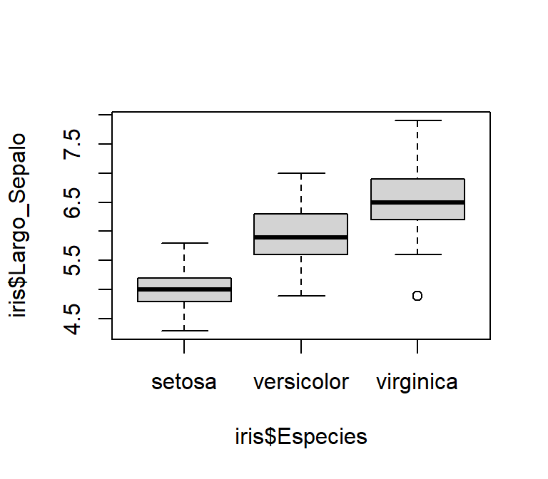

## Gráficos descriptivos: ggbarplot

```r
library(ggpubr)
ggbarplot(data = iris, x = "Especies", y = "Largo_Sepalo",
          add = "mean_sd")
```

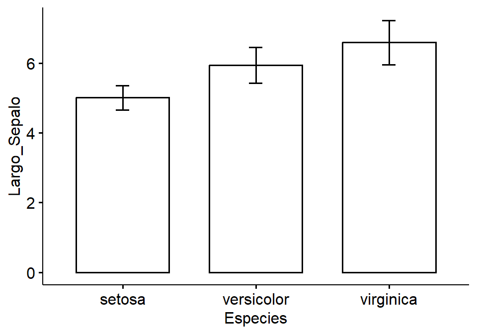

## Explorando normalidad

Antes de aplicar pruebas estadísticas es importante explorar si los datos siguen una **distribución normal** (gaussiana — forma acampanada y simétrica).

**Important**

Muchas pruebas estadísticas **asumen normalidad**. Si los datos no son normales, se deben usar pruebas no paramétricas.

Usaremos `Ancho_Sepalo` para estos ejemplos.

## Normalidad: histograma y densidad

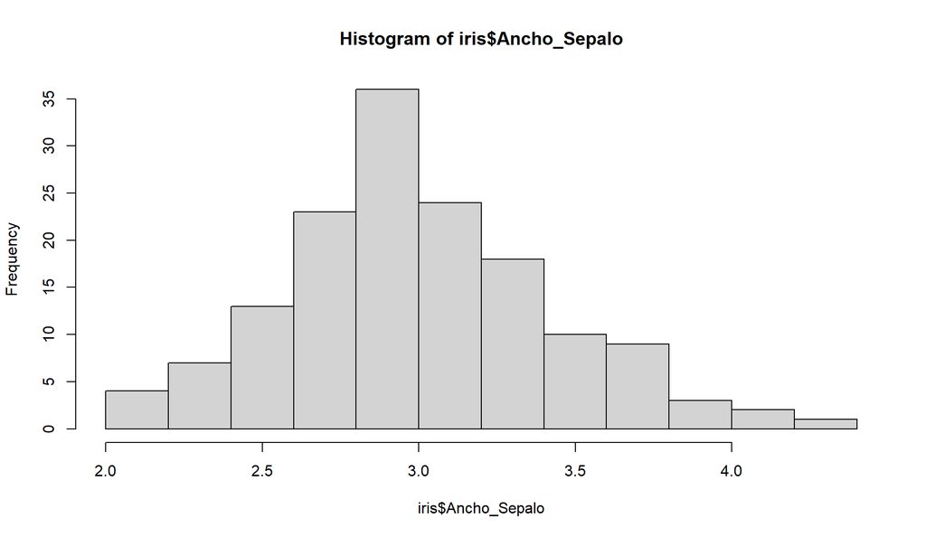

```r
hist(iris$Ancho_Sepalo)
```

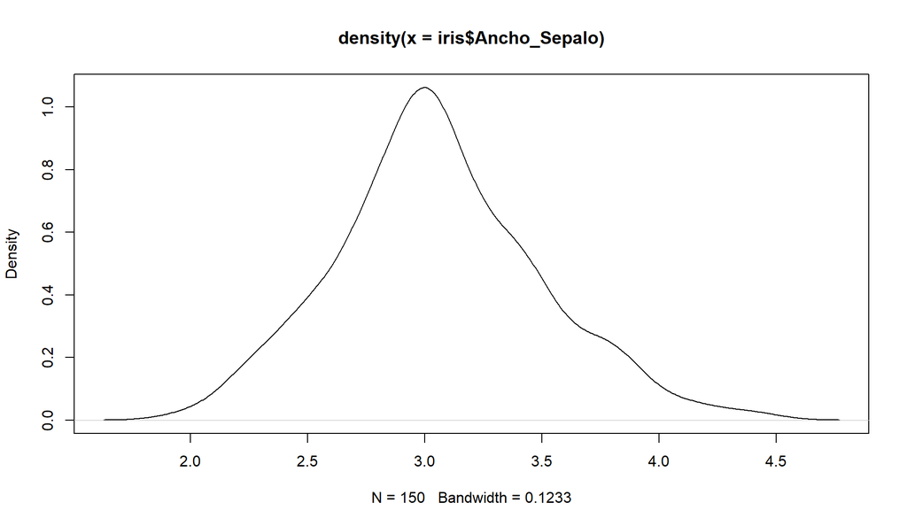

```r
plot(density(iris$Ancho_Sepalo))
```

## Normalidad: Q-Q plot

```r
qqnorm(iris$Ancho_Sepalo)
qqline(iris$Ancho_Sepalo)
```

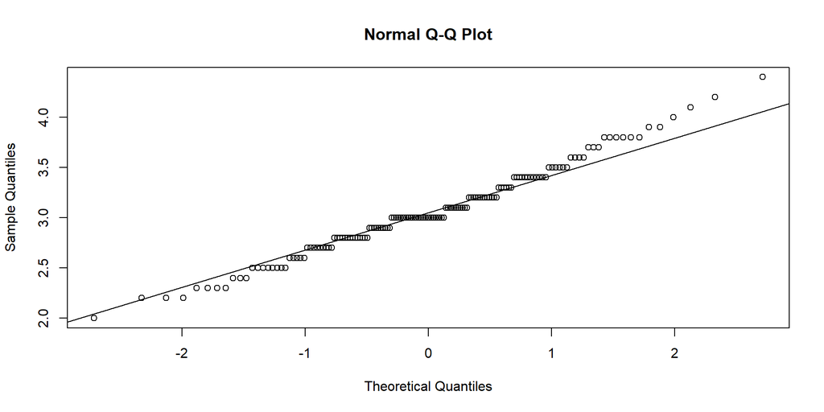

## Normalidad: `qqPlot` del paquete `car`

```r
library(car)
qqPlot(iris$Ancho_Sepalo)
```

```
[1] 16 34
```

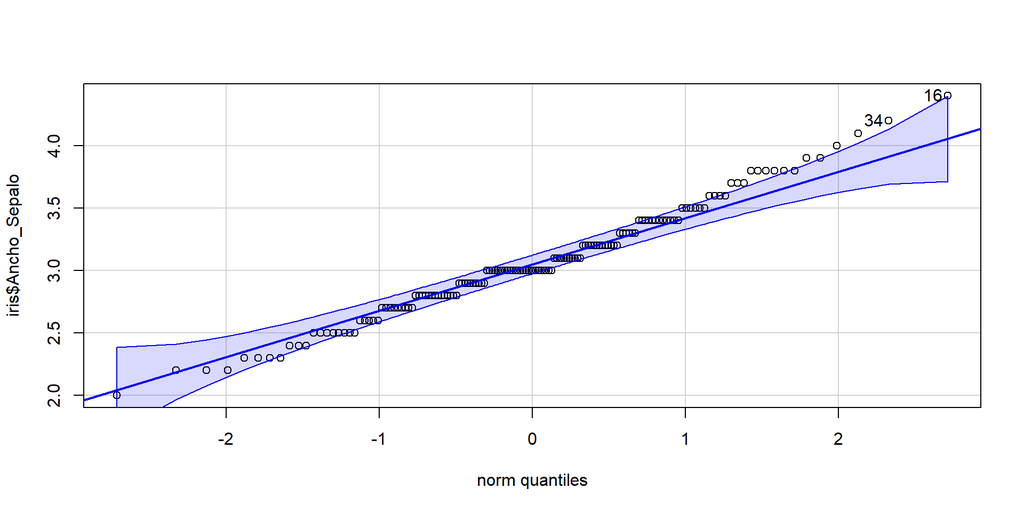

## Normalidad: prueba de Shapiro-Wilk

```r
shapiro.test(iris$Ancho_Sepalo)
```

```
    Shapiro-Wilk normality test

data:  iris$Ancho_Sepalo
W = 0.98492, p-value = 0.1012
```

**Note**

**H₀:** los datos siguen una distribución normal.

**p-value = 0.1012 > 0.05** → no rechazamos H₀ → **los datos son normales**.

Si p-value < 0.05, los datos **no** serían normales.

## Correlación: `cor.test()`

¿Existe relación entre el largo y el ancho del pétalo?

```r
cor.test(iris$Largo_Petalo, iris$Ancho_Petalo)
```

```
    Pearson's product-moment correlation

data:  iris$Largo_Petalo and iris$Ancho_Petalo
t = 43.387, df = 148, p-value < 2.2e-16
alternative hypothesis: true correlation is not equal to 0
95 percent confidence interval:
 0.9490525 0.9729853
sample estimates:
      cor
0.9628654
```

## Correlación: interpretando los resultados

- **cor = +1**: correlación positiva perfecta
- **cor = -1**: correlación negativa perfecta
- **cor = 0**: sin correlación
- **p-value < 0.05**: correlación significativa

**Tip**

En los resultados anteriores, el **cor ≈ 0.96** y el **p-value < 0.05**.

Hay una correlación positiva y significativa entre largo y ancho del pétalo.

## Correlación: función `cor()`

Solo devuelve el coeficiente, sin la prueba:

```r
cor(iris$Largo_Petalo, iris$Ancho_Petalo)             # Pearson (normales)
```

```
[1] 0.9628654
```

```r
cor(iris$Largo_Petalo, iris$Ancho_Petalo,
    method = "spearman")                              # Spearman (no normales)
```

```
[1] 0.9376668
```

## Regresión lineal

Modelo que describe la relación lineal entre dos variables: **y = ax + b**

- **a** = pendiente, **b** = intercepto
- Debe aplicarse sobre datos normales

```r
modelo <- lm(Ancho_Petalo ~ Largo_Petalo, data = iris)
plot(modelo, which = 2)    # diagnóstico de normalidad
```

La variable de respuesta va al lado izquierdo de `~`, la explicativa al derecho.

## Regresión lineal: diagnóstico

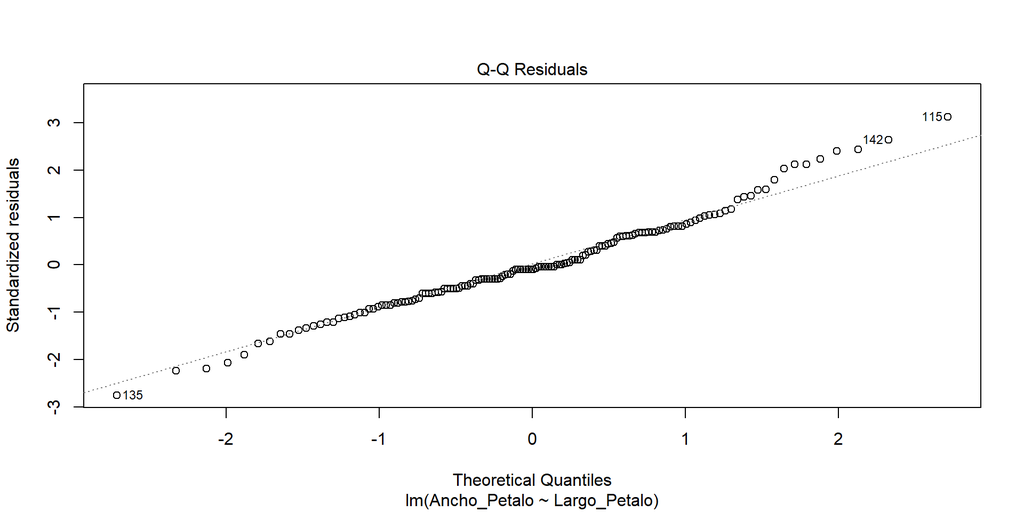

Pocos puntos fuera de la línea → asumimos normalidad.

## Regresión lineal: resumen del modelo

```r
summary(modelo)
```

```
Call:
lm(formula = Ancho_Petalo ~ Largo_Petalo, data = iris)

Residuals:
     Min       1Q   Median       3Q      Max
-0.56515 -0.12358 -0.01898  0.13288  0.64272

Coefficients:
              Estimate Std. Error t value Pr(>|t|)
(Intercept)  -0.363076   0.039762  -9.131  4.7e-16 ***
Largo_Petalo  0.415755   0.009582  43.387  < 2e-16 ***
---
Signif. codes:  0 '***' 0.001 '**' 0.01 '*' 0.05 '.' 0.1 ' ' 1

Residual standard error: 0.2065 on 148 degrees of freedom
Multiple R-squared:  0.9271,    Adjusted R-squared:  0.9266
F-statistic:  1882 on 1 and 148 DF,  p-value: < 2.2e-16
```

## Regresión lineal: interpretando

**Note**

De `summary(modelo)`:

- **Intercepto** = -0.3630, **pendiente** = 0.4157
- Ecuación: `Ancho_Petalo = 0.4157 × Largo_Petalo - 0.3630`
- **p-values < 0.05** → coeficientes significativos
- **R² ajustado ≈ 0.92** → el modelo explica el **92%** de la varianza

## ANOVA (1 vía): supuestos

ANOVA compara las medias entre diferentes grupos. Supuestos:

1. **Independencia** — cada observación es independiente
2. **Normalidad** — los datos siguen distribución normal
3. **Homocedasticidad** — varianzas equivalentes entre grupos

Verificamos 2 y 3 con gráficos diagnóstico del modelo:

```r
modelo_ancho <- lm(Ancho_Sepalo ~ Especies, data = iris)
plot(modelo_ancho, which = c(1, 2))
```

## ANOVA (1 vía): gráficos diagnóstico

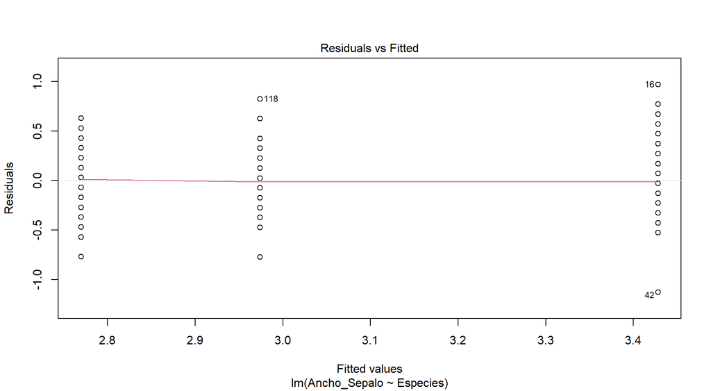

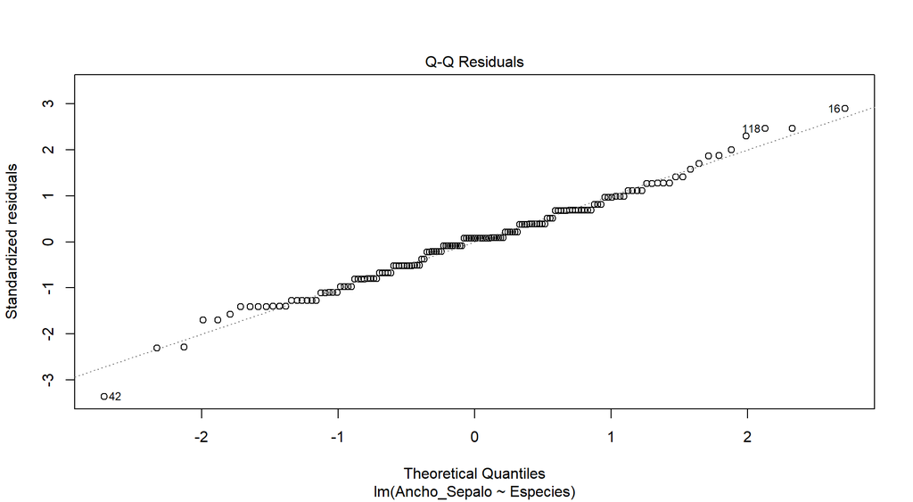

**Note**

**Residuals vs Fitted:** la línea roja debe ser aproximadamente horizontal — indica homocedasticidad. **Q-Q:** los puntos deben seguir la línea diagonal — indica normalidad.

## ANOVA (1 vía): resultado

```r
anova(modelo_ancho)
```

```
Analysis of Variance Table

Response: Ancho_Sepalo
           Df Sum Sq Mean Sq F value    Pr(>F)
Especies    2 11.345  5.6725   49.16 < 2.2e-16 ***
Residuals 147 16.962  0.1154
---
Signif. codes:  0 '***' 0.001 '**' 0.01 '*' 0.05 '.' 0.1 ' ' 1
```

**Note**

**p-value << 0.05** → rechazamos H₀ → las medias del ancho del sépalo **son diferentes entre especies**.

## Prueba de Tukey

ANOVA dice que hay diferencias, pero no dice *entre cuáles grupos*. Tukey lo determina:

```r
fm1 <- aov(modelo_ancho)
TukeyHSD(fm1, "Especies", ordered = TRUE)
```

```
  Tukey multiple comparisons of means
    95% family-wise confidence level
    factor levels have been ordered

Fit: aov(formula = modelo_ancho)

$Especies
                      diff        lwr       upr     p adj
virginica-versicolor 0.204 0.04314472 0.3648553 0.0087802
setosa-versicolor    0.658 0.49714472 0.8188553 0.0000000
setosa-virginica     0.454 0.29314472 0.6148553 0.0000000
```

## Prueba de Tukey: grupos con `HSD.test`

```r
library(agricolae)
tuk <- HSD.test(fm1, "Especies", group = TRUE, console = FALSE)
tuk$groups
```

```
           Ancho_Sepalo groups
setosa            3.428      a
virginica         2.974      b
versicolor        2.770      c
```

Las letras indican grupos significativamente diferentes entre sí.

## Prueba de Tukey: gráfica

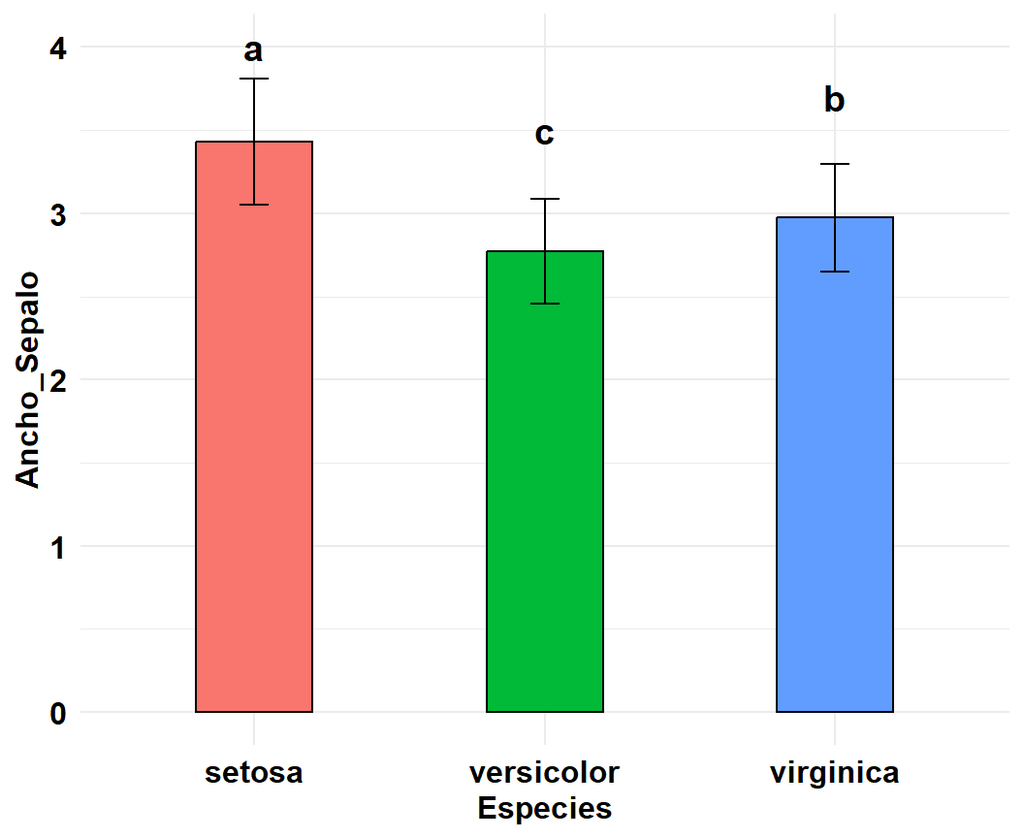

## ANOVA (2 vías): introducción

Estudia la relación entre una variable dependiente **cuantitativa** y **dos factores** cualitativos.

- **Modelo aditivo:** `aov(respuesta ~ factor1 + factor2, data)`
- **Modelo con interacción:** `aov(respuesta ~ factor1 * factor2, data)`

**Note**

Los grupos deben tener el **mismo número de réplicas**.

Usaremos el dataset `ToothGrowth`: efecto de vitamina C (dosis y forma de administración) sobre el crecimiento de dientes.

## ANOVA (2 vías): preparar los datos

```r
data("ToothGrowth")
str(ToothGrowth)
```

```
'data.frame':   60 obs. of  3 variables:
 $ len : num  4.2 11.5 7.3 5.8 6.4 10 11.2 11.2 5.2 7 ...
 $ supp: Factor w/ 2 levels "OJ","VC": 2 2 2 2 2 2 2 2 2 2 ...
 $ dose: num  0.5 0.5 0.5 0.5 0.5 0.5 0.5 0.5 0.5 0.5 ...
```

`dose` aparece como numérica — la convertimos a factor:

```r
ToothGrowth$dose <- factor(ToothGrowth$dose,
                           levels = c(0.5, 1, 2),
                           labels = c("D0.5", "D1", "D2"))
head(ToothGrowth)
```

```
   len supp dose
1  4.2   VC D0.5
2 11.5   VC D0.5
3  7.3   VC D0.5
4  5.8   VC D0.5
5  6.4   VC D0.5
6 10.0   VC D0.5
```

## ANOVA (2 vías): visualización

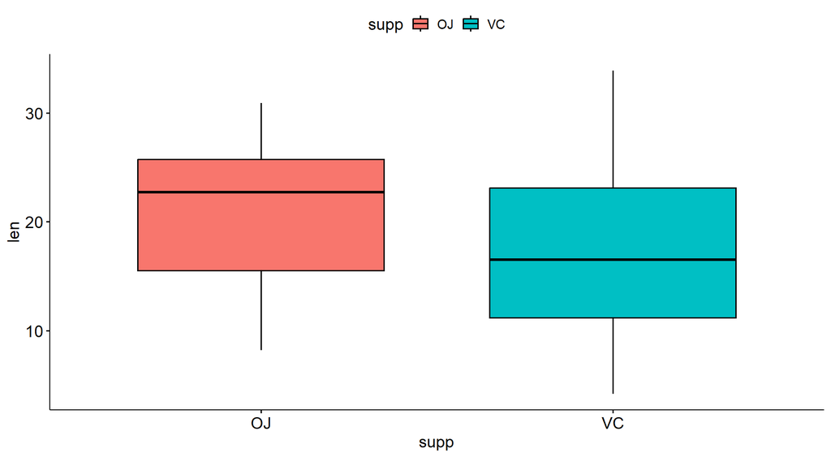

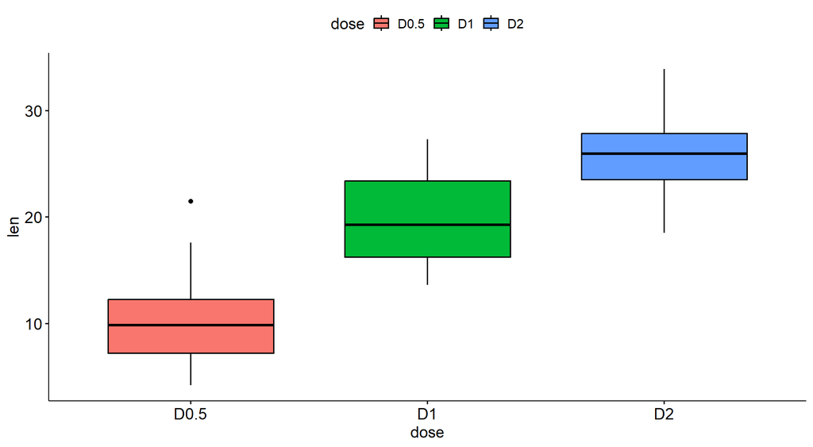

## ANOVA (2 vías): interacción entre factores

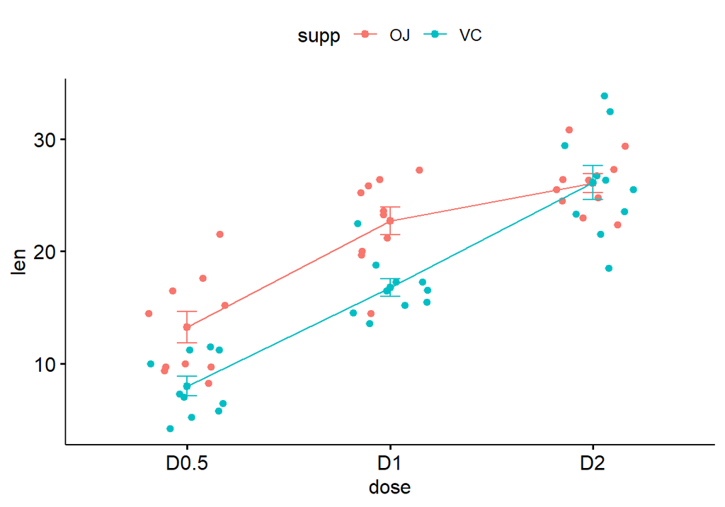

Las líneas no paralelas sugieren una posible **interacción** entre `supp` y `dose`.

## ANOVA (2 vías): modelos

```r
anova1 <- aov(len ~ supp + dose, data = ToothGrowth)   # aditivo
anova2 <- aov(len ~ supp * dose, data = ToothGrowth)   # interacción
summary(anova1)
```

```
            Df Sum Sq Mean Sq F value   Pr(>F)
supp         1  205.4   205.4   14.02 0.000429 ***
dose         2 2426.4  1213.2   82.81  < 2e-16 ***
Residuals   56  820.4    14.7
---
Signif. codes:  0 '***' 0.001 '**' 0.01 '*' 0.05 '.' 0.1 ' ' 1
```

## ANOVA (2 vías): modelo con interacción

```r
summary(anova2)
```

```
            Df Sum Sq Mean Sq F value   Pr(>F)
supp         1  205.4   205.4  15.572 0.000231 ***
dose         2 2426.4  1213.2  92.000  < 2e-16 ***
supp:dose    2  108.3    54.2   4.107 0.021860 *
Residuals   54  712.1    13.2
---
Signif. codes:  0 '***' 0.001 '**' 0.01 '*' 0.05 '.' 0.1 ' ' 1
```

**Note**

El modelo multiplicativo confirma una **interacción significativa** (p < 0.05) entre `supp` y `dose` — el efecto de un factor depende del otro.

## Otras pruebas estadísticas

| Situación | Prueba paramétrica | Prueba no paramétrica |
| --- | --- | --- |
| 2 grupos independientes | `t.test()` | `wilcox.test()` |
| 2 grupos pareados | `t.test(paired=TRUE)` | `wilcox.test(paired=TRUE)` |
| Más de 2 grupos | ANOVA | `kruskal.test()` |

```r
t.test(len ~ supp, data = ToothGrowth, paired = TRUE)
wilcox.test(len ~ supp, data = ToothGrowth, paired = TRUE)
kruskal.test(len ~ dose, data = ToothGrowth)
```

**Note**

Otros paquetes útiles: **agricolae**, **vegan**, **emmeans** — con pruebas adicionales como Dunn, Duncan, Welch.

## Referencias

- Irizarry, R.A. (2019). *Introduction to Data Science*. rafalab.dfci.harvard.edu/dsbook
- Wickham, H. & Grolemund, G. (2017). *R for Data Science*. r4ds.had.co.nz
- Kassambara, A. (2017). *Practical Statistics in R*. STHDA. sthda.com
- Bosco Mendoza, J. (2019). *R para principiantes*. bookdown.org/jboscomendoza/r-principiantes4
- CRAN — Comprehensive R Archive Network: cran.r-project.org

R básico para ciencia de datos · UAT 2026